# Modification de pages HTML

## Expression du besoin

Les caméras IP hébergent souvent des serveurs web embarqués pour accéder à leurs services. Les pages générées sont au format **HTML** (*Hypertext Markup Language*), le format de données conçu pour les représenter.

## HTML

C’est un **langage de balisage** permettant d’écrire de l’**hypertexte**. HTML permet également de structurer sémantiquement et de mettre en forme le contenu des pages, d’inclure des ressources multimédias dont des images, des formulaires de saisie, et des programmes informatiques. Il permet de créer des documents interopérables avec des équipements très variés de manière conforme aux exigences de l’accessibilité du web. Il est souvent utilisé conjointement avec des langages de programmation (*JavaScript*) et des formats de présentation (feuilles de style en cascade **CSS**).

Le langage est standardisé par le [W3C](http://www.w3.org/html/).

Liens : [cours HTML (1° partie)](http://tvaira.free.fr/web/cours-html-1.pdf) et [cours HTML (2° partie)](http://tvaira.free.fr/web/cours-html-2.pdf)

Le code HTML contenu dans une page web est interprété côté client par le navigateur.

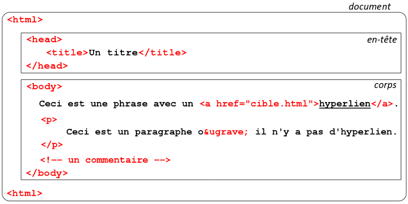

Un document HTML valide doit déclarer la version HTML qu’il utilise. La déclaration de type de document indique la définition de type de document (DTD) en vigueur pour le document. Par exemple, HTML 4.01 spécifie trois DTD (Strict, Transitoire et Frameset) et les DTD varient selon les éléments qui y sont gérés.

La spécification HTML 4.01 en français : www.la-grange.net/w3c/html4.01/.

# Objectifs

Être capable de manipuler des documents HTML.

## Séquence 1 : modifier un document HTML

Actuellement, la page `mobile.htm` de la caméra IP produit ceci :

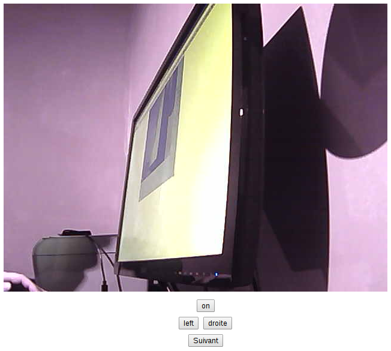

1. Modifier la page précédente pour créer une page `mobile2.htm` pour obtenir ceci :

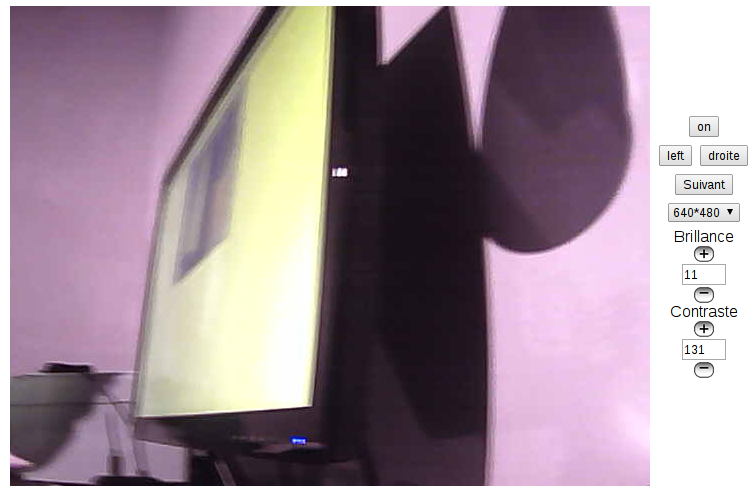

Il vous faudra accéder par telnet à la caméra afin d’accéder aux pages HTML du serveur web embarqué.

```
Ne modifier pas directement les pages actuellement stockées dans la caméra. Par contre, vous pouvez copier une page existante puis la modifier avec vi. Le copier/coller entre votre poste de travail et l'accès telnet à votre caméra est possible.
```

Pour rendre fonctionnel les changements effectués, il faudra ajouter du code **javascript**. Ceci est décrit dans l’activité Javascript.

Retour au sommaire